# Исследование данных о компьютерных играх

# Описание проекта

Вы работаете в интернет-магазине «Стримчик», который продаёт по всему миру компьютерные игры. Из открытых источников доступны исторические данные о продажах игр, оценки пользователей и экспертов, жанры и платформы (например, Xbox или PlayStation). Вам нужно выявить определяющие успешность игры закономерности. Это позволит сделать ставку на потенциально популярный продукт и спланировать рекламные кампании.

Перед вами данные до 2016 года. Представим, что сейчас декабрь 2016 г., и вы планируете кампанию на 2017-й. Нужно отработать принцип работы с данными. Неважно, прогнозируете ли вы продажи на 2017 год по данным 2016-го или же 2027-й — по данным 2026 года.

В наборе данных попадается аббревиатура ESRB (Entertainment Software Rating Board) — это ассоциация, определяющая возрастной рейтинг компьютерных игр. ESRB оценивает игровой контент и присваивает ему подходящую возрастную категорию, например, «Для взрослых», «Для детей младшего возраста» или «Для подростков».

# Цель проекта

Выявить закономерности, определяющие успешность компьютерных игр, на основе исторических данных о продажах, оценках пользователей и экспертов, жанрах и платформах. Это позволит интернет-магазину прогнозировать популярность игр, планировать рекламные кампании и делать ставки на потенциально успешные продукты для кампании 2017 года.

# Описание данных

Путь к файлу: `/datasets/games.csv`.

- `'Name'` — название игры
- `'Platform'` — платформа
- `'Year_of_Release'` — год выпуска
- `'Genre'` — жанр игры
- `'NA_sales'` — продажи в Северной Америке (миллионы проданных копий)
- `'EU_sales'` — продажи в Европе (миллионы проданных копий)
- `'JP_sales'` — продажи в Японии (миллионы проданных копий)
- `'Other_sales'` — продажи в других странах (миллионы проданных копий)
- `'Critic_Score'` — оценка критиков (максимум 100)
- `'User_Score'` — оценка пользователей (максимум 10)
- `'Rating'` — рейтинг от организации ESRB (англ. Entertainment Software Rating Board). Эта ассоциация определяет рейтинг компьютерных игр и присваивает им подходящую возрастную категорию.

Данные за 2016 год могут быть неполными.

# План работы

1. Открыть файл с данными и изучить общую информацию.
2. Провести предобработку данных:
- Заменить названия столбцов.
- Преобразовать данные в нужные типы.
- Обработать пропуски при необходимости.
- Создать столбец с посчитанными суммарными продажами во всех регионах.
1. Провести исследовательский анализ данных:
- Сколько игр выпускалось в разные годы.
- Как менялись продажи по платформам. Среди платформ с наибольшими суммарными продажами построить распределение по годам. За какой характерный срок появляются новые и исчезают старые платформы?
- Выделить данные за актуальный период.
- Какие платформы лидируют по продажам, растут или падают? Выбрать несколько потенциально прибыльных платформ.
- Как влияют на продажи внутри платформ отзывы пользователей и критиков?
- Общее распределение игр по жанрам. Что можно сказать о самых прибыльных жанрах? Выделяются ли жанры с высокими и низкими продажами?
1. Составить портрет пользователя каждого региона:
- Самые популярные платформы (топ-5).
- Самые популярные жанры (топ-5).
- Влияние рейтинга ESRB на продажи в регионах.
1. Проверить гипотезы:
- Средние пользовательские рейтинги платформ Xbox One и PC одинаковые.
- Средние пользовательские рейтинги жанров Action и Sports разные.

# Содержание

## Загрузка данных

### Импорт библиотек и загрузка данных файла

Импортируем необходимые для работы библиотеки.

```python
import pandas as pd
import matplotlib.pyplot as plt
import seaborn as sns
from scipy import stats
```

### Создание функций

Создадим функции, которые нам потребуются в работе.

```python
# Функция для предварительного изучения общей информации о данных
def data_research(dataset):

    display(dataset.head())
    display(dataset.tail())
    print()

    print('-----Общая информация о данных-----\n')
    print(dataset.info())

    print('\n\n-----Количество пропущенных значений-----\n')
    print(dataset.isna().sum())

    print('\n\n-----Доля пропущенных значений-----\n')
    print(f'Во всем датафрейме: '\
          f'{round((dataset.isna().sum().sum() / (dataset.shape[0] * dataset.shape[1]) * 100), 1)}%\n')
    print('В каждом столбце:')
    display(pd.DataFrame(dataset.isna().mean()*100).style.set_precision(1).background_gradient('coolwarm'))

    print('\n\n-----Описание данных-----')
    display(dataset.describe())

    print('\n\n-----Гистограммы для всех числовых столбцов таблицы-----\n')
    axes = dataset.hist(figsize=(10, 10))

        # Добавляем подписи осей
    for ax in axes.flatten():
        ax.set_xlabel(ax.get_title(), fontsize=12)
        ax.set_ylabel('Количество записей', fontsize=12)

    plt.tight_layout()
    plt.show()
```

```python
# Функция для изучения информации о пропущенных значениях
def empty_cells(column):
    print('Количество пропущенных значений в столбце:',
          data.loc[data[column].isna()].shape[0])

    print(f'Доля пропущенных значений в столбце:', \
          f'{round(data.loc[data[column].isna()].shape[0] / data.shape[0] * 100, 2)}%')

    display(data.loc[data[column].isna()].head())
```

```python
# Функция для построения сводной таблицы по суммарным продажам игр
def games_sales_pivot(data, region, column):
    result = data.pivot_table(index=column,
                              values=region,
                              aggfunc='sum')\
                 .sort_values(by=region,
                              ascending=False)
    return result
```

```python
# Функция для построения диаграмм по регионам
def regions_pie_plots(column, name):
    # Создаем фигуру и оси, добавляем общий заголовок
    fig, axs = plt.subplots(1, 3, figsize=(18, 6))
    fig.suptitle(f'Самые популярные {name} в регионах')

    # Для каждого региона cоздаем сводную таблицу при помощи ранее созданной функции `games_sales_pivot`
    for i, region in enumerate(actual_data.columns[4:7]):
        region_sales = games_sales_pivot(actual_data, region, column)

        # Оставляем топ-5 значений и объединяем остальные в 'others'
        top = region_sales.head(5).copy()
        if column != 'rating':
            top.loc['Others'] = region_sales.tail(len(region_sales) - 5)[region].sum()

        # Создаем круговую диаграмму и добавляем подзаголовок
        axs[i].pie(top[region].values, labels=top.index, autopct='%1.1f%%')
        axs[i].set_title(['Северная Америка', 'Европа', 'Япония'][i])

    plt.show()
```

### Загрузка данных файла

Загружаем данные из csv-файла в датафрейм.

```python
data = pd.read_csv('/datasets/games.csv')
```

### Изучение общей информации о датафрейме

Изучим информацию при помощи функции `data_research`.

[output not shown]

[output not shown]

[output not shown]

[output not shown]

```
-----Описание данных-----
```

[output not shown]

```
-----Гистограммы для всех числовых столбцов таблицы-----
```

[figure not shown]

```python
data_research(data)
```

### Вывод

Можно увидеть, что данные представлены за период с 1980 по 2016 годы, но за последний год данные неполные.

Необходимо исправить наименование всех столбцов, приведя их к нижнему регистру.

В столбце `'Year_of_Release'` указан неверный тип данных, поэтому его нужно заменить на `'int'`. Также в столбце `'User_Score'` типом данных указан `'object'`, когда как такие данные могут быть пресдтавлены только в виде `'float'`, поэтому его необходимо исправить.

## Предобработка данных

На этапе предобработки нам необходимо:

- привести наименования столбцов к нижнему регистру.
- исправить некорректные типы данных в столбцах.
- добавить новый столбец `'total_sales'`.
- проверить данные на наличие дубликатов.
- изучить пропущенные значения в столбцах.

### Изменение наименования столбцов

Приведем наименования столбцов к нижнему регистру.

```python
data.columns = data.columns.str.lower()
```

Проверяем результат.

```python
data.columns
```

```
Index(['name', 'platform', 'year_of_release', 'genre', 'na_sales', 'eu_sales',
       'jp_sales', 'other_sales', 'critic_score', 'user_score', 'rating'],
      dtype='object')
```

Теперь наименования столбцов отображаются корректно.

### Изменение типа данных в столбцах

В столбце `'year_of_release'` указан тип данных `'float'`, поэтому его нужно заменить на `'int'`.

Также в столбце `'user_score'` типом данных указан `'object'`, когда как такие данные могут быть представлены только в виде `'float'`, поэтому его необходимо исправить.

#### Cтолбец `'year_of_release'`

Проверим уникальные значения столбца.

```python
data['year_of_release'].unique()
```

```
array([2006., 1985., 2008., 2009., 1996., 1989., 1984., 2005., 1999.,
       2007., 2010., 2013., 2004., 1990., 1988., 2002., 2001., 2011.,
       1998., 2015., 2012., 2014., 1992., 1997., 1993., 1994., 1982.,
       2016., 2003., 1986., 2000.,   nan, 1995., 1991., 1981., 1987.,
       1980., 1983.])
```

Среди значений ошибок нет, поэтому просто меняем тип данных на `'int'`.

```python
data['year_of_release'] = data['year_of_release'].astype('Int64')
```

Проверяем результат.

```python
data['year_of_release'].unique()
```

```
<IntegerArray>
[2006, 1985, 2008, 2009, 1996, 1989, 1984, 2005, 1999, 2007, 2010, 2013, 2004,
 1990, 1988, 2002, 2001, 2011, 1998, 2015, 2012, 2014, 1992, 1997, 1993, 1994,
 1982, 2016, 2003, 1986, 2000, <NA>, 1995, 1991, 1981, 1987, 1980, 1983]
Length: 38, dtype: Int64
```

Теперь годы отображаются корректно в виде целых чисел.

#### Столбец `'user_score'`

Проверим уникальные значения столбца.

```python
data['user_score'].unique()
```

```
array(['8', nan, '8.3', '8.5', '6.6', '8.4', '8.6', '7.7', '6.3', '7.4',
       '8.2', '9', '7.9', '8.1', '8.7', '7.1', '3.4', '5.3', '4.8', '3.2',
       '8.9', '6.4', '7.8', '7.5', '2.6', '7.2', '9.2', '7', '7.3', '4.3',
       '7.6', '5.7', '5', '9.1', '6.5', 'tbd', '8.8', '6.9', '9.4', '6.8',
       '6.1', '6.7', '5.4', '4', '4.9', '4.5', '9.3', '6.2', '4.2', '6',
       '3.7', '4.1', '5.8', '5.6', '5.5', '4.4', '4.6', '5.9', '3.9',
       '3.1', '2.9', '5.2', '3.3', '4.7', '5.1', '3.5', '2.5', '1.9', '3',
       '2.7', '2.2', '2', '9.5', '2.1', '3.6', '2.8', '1.8', '3.8', '0',
       '1.6', '9.6', '2.4', '1.7', '1.1', '0.3', '1.5', '0.7', '1.2',
       '2.3', '0.5', '1.3', '0.2', '0.6', '1.4', '0.9', '1', '9.7'],
      dtype=object)
```

Можно заметить, что все числа написаны в формате строк, а также присутствует значение `'tbd'`.

TBD (To Be Determined) – английская аббревиатура, которая означает «будет определено». Она используется для указания на неопределенность или незавершенность чего-либо на данный момент.

В данном контексте это означает, что игра не получила достаточного количества оценок от игроков для определения ее окончательной оценки.

Взглянем на эти данные.

```python
print('Количество игр с оценкой "tbd":',
      data['user_score'][data['user_score'] == 'tbd'].count())
data[data['user_score'] == 'tbd'].head(10)
```

```
Количество игр с оценкой "tbd": 2424
```

|  | name | platform | year_of_release | genre | na_sales | eu_sales | jp_sales | other_sales | critic_score | user_score | rating |
| --- | --- | --- | --- | --- | --- | --- | --- | --- | --- | --- | --- |
| 119 | Zumba Fitness | Wii | 2010 | Sports | 3.45 | 2.59 | 0.00 | 0.66 | NaN | tbd | E |
| 301 | Namco Museum: 50th Anniversary | PS2 | 2005 | Misc | 2.08 | 1.35 | 0.00 | 0.54 | 61.0 | tbd | E10+ |
| 520 | Zumba Fitness 2 | Wii | 2011 | Sports | 1.51 | 1.03 | 0.00 | 0.27 | NaN | tbd | T |
| 645 | uDraw Studio | Wii | 2010 | Misc | 1.65 | 0.57 | 0.00 | 0.20 | 71.0 | tbd | E |
| 657 | Frogger's Adventures: Temple of the Frog | GBA | <NA> | Adventure | 2.15 | 0.18 | 0.00 | 0.07 | 73.0 | tbd | E |
| 718 | Just Dance Kids | Wii | 2010 | Misc | 1.52 | 0.54 | 0.00 | 0.18 | NaN | tbd | E |
| 726 | Dance Dance Revolution X2 | PS2 | 2009 | Simulation | 1.09 | 0.85 | 0.00 | 0.28 | NaN | tbd | E10+ |
| 821 | The Incredibles | GBA | 2004 | Action | 1.15 | 0.77 | 0.04 | 0.10 | 55.0 | tbd | E |
| 881 | Who wants to be a millionaire | PC | 1999 | Misc | 1.94 | 0.00 | 0.00 | 0.00 | NaN | tbd | E |
| 1047 | Tetris Worlds | GBA | 2001 | Puzzle | 1.25 | 0.39 | 0.00 | 0.06 | 65.0 | tbd | E |

Мы можем видеть, что здесь присутствуют даже те игры, которые были выпущены более чем 20 лет назад.

2424 игр - это 14,5% от всего объема данных, что довольно много. Лучше всего будет заменить эти значения на `NaN`, чтобы оставалась возможность проводить анализ и расчеты по данным этого столбца.

Сперва посмотрим, сколько пропусков сейчас в этом столбце.

```python
data.loc[data['user_score'].isna()].shape[0]
```

```
6701
```

Заменяем `'tbd'` на `NaN`.

```python
data.loc[data['user_score'] == 'tbd', 'user_score'] = float('nan')
```

Проверяем результат.

```python
data.loc[data['user_score'].isna()].shape[0]
```

```
9125
```

```python
print('Количество игр с оценкой "tbd":',
      data['user_score'][data['user_score'] == 'tbd'].count())
```

```
Количество игр с оценкой "tbd": 0
```

К пропускам прибавилось 2424 значений, а `'tbd'` больше не отображается. Теперь мы можем поменять тип данных на `'float'`.

```python
data['user_score'] = data['user_score'].astype('float64')
```

Проверяем результат.

```python
data['user_score'].unique()
```

```
array([8. , nan, 8.3, 8.5, 6.6, 8.4, 8.6, 7.7, 6.3, 7.4, 8.2, 9. , 7.9,
       8.1, 8.7, 7.1, 3.4, 5.3, 4.8, 3.2, 8.9, 6.4, 7.8, 7.5, 2.6, 7.2,
       9.2, 7. , 7.3, 4.3, 7.6, 5.7, 5. , 9.1, 6.5, 8.8, 6.9, 9.4, 6.8,
       6.1, 6.7, 5.4, 4. , 4.9, 4.5, 9.3, 6.2, 4.2, 6. , 3.7, 4.1, 5.8,
       5.6, 5.5, 4.4, 4.6, 5.9, 3.9, 3.1, 2.9, 5.2, 3.3, 4.7, 5.1, 3.5,
       2.5, 1.9, 3. , 2.7, 2.2, 2. , 9.5, 2.1, 3.6, 2.8, 1.8, 3.8, 0. ,
       1.6, 9.6, 2.4, 1.7, 1.1, 0.3, 1.5, 0.7, 1.2, 2.3, 0.5, 1.3, 0.2,
       0.6, 1.4, 0.9, 1. , 9.7])
```

Значения `'tbd'` больше нет, все другие занчения указаны в формате вещественных чисел.

### Добавление столбца `'total_sales'`

Добавим столбец `'total_sales'`, в котором будет посчитаны суммарные продажи во всех регионах.

```python
data['total_sales'] = data[['na_sales', 'eu_sales', 'jp_sales', 'other_sales']].sum(axis=1)
```

Проверяем результат.

```python
data.head()
```

|  | name | platform | year_of_release | genre | na_sales | eu_sales | jp_sales | other_sales | critic_score | user_score | rating | total_sales |
| --- | --- | --- | --- | --- | --- | --- | --- | --- | --- | --- | --- | --- |
| 0 | Wii Sports | Wii | 2006 | Sports | 41.36 | 28.96 | 3.77 | 8.45 | 76.0 | 8.0 | E | 82.54 |
| 1 | Super Mario Bros. | NES | 1985 | Platform | 29.08 | 3.58 | 6.81 | 0.77 | NaN | NaN | NaN | 40.24 |
| 2 | Mario Kart Wii | Wii | 2008 | Racing | 15.68 | 12.76 | 3.79 | 3.29 | 82.0 | 8.3 | E | 35.52 |
| 3 | Wii Sports Resort | Wii | 2009 | Sports | 15.61 | 10.93 | 3.28 | 2.95 | 80.0 | 8.0 | E | 32.77 |
| 4 | Pokemon Red/Pokemon Blue | GB | 1996 | Role-Playing | 11.27 | 8.89 | 10.22 | 1.00 | NaN | NaN | NaN | 31.38 |

В конце таблицы мы видим, что новый столбец отображается, и информация в нем корректна.

### Устранение дубликатов

#### Явные дубликаты

Сперва проверим, нет ли в таблице явных дубликатов.

```python
data.duplicated().sum()
```

```
0
```

Явных дубликатов в таблице нет, но мы можем проверить на наличие дубликатов только по части столбцов - игры, у которых одновременно совпадают значения в столбцах `'name'`, `'platform'` и `'year_of_release'`.

```python
data[['name', 'platform', 'year_of_release']].duplicated().sum()
```

```
2
```

В таблице присутствуют 2 совпадающих пар игр, изучим их подробнее.

```python
data[data.duplicated(subset=['name', 'platform', 'year_of_release'], keep=False)]
```

|  | name | platform | year_of_release | genre | na_sales | eu_sales | jp_sales | other_sales | critic_score | user_score | rating | total_sales |
| --- | --- | --- | --- | --- | --- | --- | --- | --- | --- | --- | --- | --- |
| 604 | Madden NFL 13 | PS3 | 2012 | Sports | 2.11 | 0.22 | 0.00 | 0.23 | 83.0 | 5.5 | E | 2.56 |
| 659 | NaN | GEN | 1993 | NaN | 1.78 | 0.53 | 0.00 | 0.08 | NaN | NaN | NaN | 2.39 |
| 14244 | NaN | GEN | 1993 | NaN | 0.00 | 0.00 | 0.03 | 0.00 | NaN | NaN | NaN | 0.03 |
| 16230 | Madden NFL 13 | PS3 | 2012 | Sports | 0.00 | 0.01 | 0.00 | 0.00 | 83.0 | 5.5 | E | 0.01 |

В результате мы видим одну пару игр, которая действительно дублируется - это "Madden NFL 13". Вероятно, по какой-то причине некоторые продажи по этим играм были засчитаны отдельным результатом, что и породило задвоение.

Также есть две строки с пропусками, но мы вернемся к ним позже, при обработке пропущенных значений.

В игре "Madden NFL 13" совпадают все значения, кроме продаж. Необходимо суммировать по этим играм значения столбцов с продажами в одной строке.

```python
for col in ['na_sales', 'eu_sales', 'jp_sales', 'other_sales', 'total_sales']:
    data.loc[(data['name'] == 'Madden NFL 13') & (data['platform'] == 'PS3'), col] = \
    data.loc[(data['name'] == 'Madden NFL 13') & (data['platform'] == 'PS3'), col].sum()
```

Проверяем результат.

```python
data.duplicated().sum()
```

```
1
```

```python
data[data.duplicated()]
```

|  | name | platform | year_of_release | genre | na_sales | eu_sales | jp_sales | other_sales | critic_score | user_score | rating | total_sales |
| --- | --- | --- | --- | --- | --- | --- | --- | --- | --- | --- | --- | --- |
| 16230 | Madden NFL 13 | PS3 | 2012 | Sports | 2.11 | 0.23 | 0.0 | 0.23 | 83.0 | 5.5 | E | 2.57 |

Теперь в строках игры "Madden NFL 13" совпадают все значения, мы сделали из них явные дубликаты по всем столбцам. Удалим дублирующую строку.

```python
data = data.drop_duplicates().reset_index(drop=True)
```

```python
data.duplicated().sum()
```

```
0
```

Мы избавились от 1 дубликата, можно идти дальше.

#### Неявные дубликаты

Столбцы, которые мы можем проверить на наличие неявнях дубликатов - это `'name'`, `'platform'`, `'genre'` и `'rating'`.

Изучим уникальные значения в каждом столбце.

##### Столбец `'name'`

Столбец `'name'` мы не сможем проверить на наличие дубликатов, т.к. там слишком много уникальных значений.

```python
print('Количество уникальных значений в столбце:',
      len(data['name'].unique()))
```

```
Количество уникальных значений в столбце: 11560
```

Также в столбце `'name'` есть уникальные значения, которые упоминаются больше одного раза, но их слишком много, чтобы их проверить. Вероятнее всего, это те игры, которые были выпущены на нескольких платформах.

```python
print('Количество уникальных значений, которые встречаются в столбце больше одного раза:',
      sum(data['name'].value_counts() > 1))
```

```
Количество уникальных значений, которые встречаются в столбце больше одного раза: 2805
```

##### Столбец `'platform'`

```python
print('Количество уникальных значений в столбце:',
      len(data['platform'].unique()))
sorted(data['platform'].unique())
```

```
Количество уникальных значений в столбце: 31
```

```
['2600',
 '3DO',
 '3DS',
 'DC',
 'DS',
 'GB',
 'GBA',
 'GC',
 'GEN',
 'GG',
 'N64',
 'NES',
 'NG',
 'PC',
 'PCFX',
 'PS',
 'PS2',
 'PS3',
 'PS4',
 'PSP',
 'PSV',
 'SAT',
 'SCD',
 'SNES',
 'TG16',
 'WS',
 'Wii',
 'WiiU',
 'X360',
 'XB',
 'XOne']
```

Все перечисленные платформы действительно существуют, ошибок в них не обнаружено.

Расшифровка каждой из упомянутых игровых платформ:

- `'2600'` — Atari 2600, домашняя игровая консоль, выпущенная Atari.
- `'3DO'` — 3DO Interactive Multiplayer, домашняя игровая консоль, выпущенная The 3DO Company.
- `'3DS'` — Nintendo 3DS, портативная игровая консоль, выпущенная Nintendo.
- `'DC'` — Dreamcast, игровая консоль, выпущенная Sega.
- `'DS'` — Nintendo DS, портативная игровая консоль, выпущенная Nintendo.
- `'GB'` — Game Boy, портативная игровая консоль, выпущенная Nintendo.
- `'GBA'` — Game Boy Advance, портативная игровая консоль, выпущенная Nintendo.
- `'GC'` — GameCube, домашняя игровая консоль, выпущенная Nintendo.
- `'GEN'` — Sega Genesis, домашняя игровая консоль, выпущенная Sega.
- `'GG'` — Game Gear, портативная игровая консоль, выпущенная Sega.
- `'N64'` — Nintendo 64, домашняя игровая консоль, выпущенная Nintendo.
- `'NES'` — Nintendo Entertainment System, домашняя игровая консоль, выпущенная Nintendo.
- `'NG'` — Neo Geo, домашняя игровая консоль, выпущенная SNK.
- `'PC'` — общее обозначение для игр, предназначенных для персональных компьютеров.
- `'PCFX'` — PC-FX, домашняя игровая консоль, выпущенная NEC.
- `'PS'` — PlayStation, домашняя игровая консоль, выпущенная Sony.
- `'PS2'` — PlayStation 2, домашняя игровая консоль, выпущенная Sony.
- `'PS3'` — PlayStation 3, домашняя игровая консоль, выпущенная Sony.
- `'PS4'` — PlayStation 4, домашняя игровая консоль, выпущенная Sony.
- `'PSP'` — PlayStation Portable, портативная игровая консоль, выпущенная Sony.
- `'PSV'` — PlayStation Vita, портативная игровая консоль, выпущенная Sony.
- `'SAT'` — Sega Saturn, домашняя игровая консоль, выпущенная Sega.
- `'SCD'` — Sega CD, дополнение к Sega Genesis, выпущенное Sega.
- `'SNES'` — Super Nintendo Entertainment System, домашняя игровая консоль, выпущенная Nintendo.
- `'TG16'` — TurboGrafx-16, домашняя игровая консоль, выпущенная NEC.
- `'WS'` — WonderSwan, портативная игровая консоль, выпущенная Bandai.
- `'Wii'` — Wii, домашняя игровая консоль, выпущенная Nintendo.
- `'WiiU'` — Wii U, домашняя игровая консоль, выпущенная Nintendo.
- `'X360'` — Xbox 360, домашняя игровая консоль, выпущенная Microsoft.
- `'XB'` — Xbox, домашняя игровая консоль, выпущенная Microsoft.
- `'XOne'` — Xbox One, домашняя игровая консоль, выпущенная Microsoft.

##### Столбец `'genre'`

```python
print('Количество уникальных значений в столбце:',
      len(data['genre'].unique()))
data['genre'].unique()
```

```
Количество уникальных значений в столбце: 13
```

```
array(['Sports', 'Platform', 'Racing', 'Role-Playing', 'Puzzle', 'Misc',
       'Shooter', 'Simulation', 'Action', 'Fighting', 'Adventure',
       'Strategy', nan], dtype=object)
```

Здесь также всё корректно, дубликаты отсутствуют.

Обозначение жанров игр:

- `'Action'` — экшн-игры.
- `'Adventure'` — приключенческие игры.
- `'Fighting'` — файтинги.
- `'Misc'` — игры, которые не подходят под другие категории или жанры.
- `'Platform'` — платформеры.
- `'Puzzle'` — головоломки.
- `'Racing'` — гонки.
- `'Role-Playing'` — ролевые игры (RPG).
- `'Shooter'` — шутеры.
- `'Simulation'` — симуляционные игры.
- `'Sports'` — спортивные игры.
- `'Strategy'` — стратегические игры.

##### Столбец `'rating'`

```python
print('Количество уникальных значений в столбце:',
      len(data['rating'].unique()))
data['rating'].unique()
```

```
Количество уникальных значений в столбце: 9
```

```
array(['E', nan, 'M', 'T', 'E10+', 'K-A', 'AO', 'EC', 'RP'], dtype=object)
```

Согласно ESRB (Entertainment Software Rating Board) существуют следующие категории рейтинга:

- `'EC'` (Early childhood) — Для детей младшего возраста.
- `'E'` (Everyone) — Для всех. Первоначально `'K-A'` (Kids to Adults).
- `'E10+'` (Everyone 10 and older) — Для всех от 10 лет и старше.
- `'T'` (Teen) — Подросткам: Игра подходит для лиц от 13 лет.
- `'M'` (Mature) — Для взрослых: Материалы игры не подходят для лиц младше 17 лет.
- `'AO'` (Adults Only 18+) — Только для взрослых.
- `'RP'` (Rating Pending) — Рейтинг ожидается.

Как мы видим, в списке присутствует один неявный дубликат - `'K-A'`, устаревшее наименование категории `'E'`.

Проверим количество значений по каждой категории.

```python
print('Количество игр с рейтингом "E":',
      data['rating'][data['rating'] == 'E'].count())
print('Количество игр с рейтингом "K-A":',
      data['rating'][data['rating'] == 'K-A'].count())
```

```
Количество игр с рейтингом "E": 3989
Количество игр с рейтингом "K-A": 3
```

У устаревшего значения `'K-A'` всего 3 игры, Заменим его на `'E'`.

```python
data.loc[data['rating'] == 'K-A', 'rating'] = 'E'
```

Проверяем результат.

```python
print('Количество игр с рейтингом "E":',
      data['rating'][data['rating'] == 'E'].count())
print('Количество игр с рейтингом "K-A":',
      data['rating'][data['rating'] == 'K-A'].count())
```

```
Количество игр с рейтингом "E": 3992
Количество игр с рейтингом "K-A": 0
```

Во всём датафрейме был обнаружен и обработан 1 неявный дубликат среди уникальных значений столбца `'rating'`. Теперь дубликатов нет, можно переходить к следующему этапу.

### Проверка пропущенных значений

Проверим пропущенные значения в столбцах `'name'`, `'year_of_release'`, `'genre'`, `'critic_score'`, `'user_score'` и`'rating'`.

Для изучения информации о пропущенных значениях будем использовать функцию `empty_cells`.

#### Столбцы `'name'` и `'genre'`

```python
empty_cells('name')
```

```
Количество пропущенных значений в столбце: 2
Доля пропущенных значений в столбце: 0.01%
```

|  | name | platform | year_of_release | genre | na_sales | eu_sales | jp_sales | other_sales | critic_score | user_score | rating | total_sales |
| --- | --- | --- | --- | --- | --- | --- | --- | --- | --- | --- | --- | --- |
| 659 | NaN | GEN | 1993 | NaN | 1.78 | 0.53 | 0.00 | 0.08 | NaN | NaN | NaN | 2.39 |
| 14244 | NaN | GEN | 1993 | NaN | 0.00 | 0.00 | 0.03 | 0.00 | NaN | NaN | NaN | 0.03 |

Пропущенные значения в столбце `'name'` совпадают с пропущенными значениями в столбце `'genre'`, т.к. их одинаковое количество.

```python
empty_cells('genre')
```

```
Количество пропущенных значений в столбце: 2
Доля пропущенных значений в столбце: 0.01%
```

|  | name | platform | year_of_release | genre | na_sales | eu_sales | jp_sales | other_sales | critic_score | user_score | rating | total_sales |
| --- | --- | --- | --- | --- | --- | --- | --- | --- | --- | --- | --- | --- |
| 659 | NaN | GEN | 1993 | NaN | 1.78 | 0.53 | 0.00 | 0.08 | NaN | NaN | NaN | 2.39 |
| 14244 | NaN | GEN | 1993 | NaN | 0.00 | 0.00 | 0.03 | 0.00 | NaN | NaN | NaN | 0.03 |

У этих двух игр много пропущенной информации - восстановить ее не получится, поэтому ценности они не имеют. Удалим их из датафрейма.

```python
data = data.dropna(subset=['name'])
```

Проверяем результат.

```python
print('Количество пропущенных значений в столбце:',
      data['name'].isna().sum())
```

```
Количество пропущенных значений в столбце: 0
```

#### Столбец `'year_of_release'`

```python
empty_cells('year_of_release')
```

```
Количество пропущенных значений в столбце: 269
Доля пропущенных значений в столбце: 1.61%
```

|  | name | platform | year_of_release | genre | na_sales | eu_sales | jp_sales | other_sales | critic_score | user_score | rating | total_sales |
| --- | --- | --- | --- | --- | --- | --- | --- | --- | --- | --- | --- | --- |
| 183 | Madden NFL 2004 | PS2 | <NA> | Sports | 4.26 | 0.26 | 0.01 | 0.71 | 94.0 | 8.5 | E | 5.24 |
| 377 | FIFA Soccer 2004 | PS2 | <NA> | Sports | 0.59 | 2.36 | 0.04 | 0.51 | 84.0 | 6.4 | E | 3.50 |
| 456 | LEGO Batman: The Videogame | Wii | <NA> | Action | 1.80 | 0.97 | 0.00 | 0.29 | 74.0 | 7.9 | E10+ | 3.06 |
| 475 | wwe Smackdown vs. Raw 2006 | PS2 | <NA> | Fighting | 1.57 | 1.02 | 0.00 | 0.41 | NaN | NaN | NaN | 3.00 |
| 609 | Space Invaders | 2600 | <NA> | Shooter | 2.36 | 0.14 | 0.00 | 0.03 | NaN | NaN | NaN | 2.53 |

Удалим пропуски. Доля пропущенных значений совсем небольшая, поэтому их удаление не повлияет на результат.

```python
data = data.dropna(subset=['year_of_release'])
```

Проверяем результат.

```python
print('Количество пропущенных значений в столбце:',
      data['year_of_release'].isna().sum())
```

```
Количество пропущенных значений в столбце: 0
```

#### Столбцы `'critic_score'` и `'user_score'`

**Столбец `'critic_score'`**

```python
empty_cells('critic_score')
```

```
Количество пропущенных значений в столбце: 8461
Доля пропущенных значений в столбце: 51.46%
```

|  | name | platform | year_of_release | genre | na_sales | eu_sales | jp_sales | other_sales | critic_score | user_score | rating | total_sales |
| --- | --- | --- | --- | --- | --- | --- | --- | --- | --- | --- | --- | --- |
| 1 | Super Mario Bros. | NES | 1985 | Platform | 29.08 | 3.58 | 6.81 | 0.77 | NaN | NaN | NaN | 40.24 |
| 4 | Pokemon Red/Pokemon Blue | GB | 1996 | Role-Playing | 11.27 | 8.89 | 10.22 | 1.00 | NaN | NaN | NaN | 31.38 |
| 5 | Tetris | GB | 1989 | Puzzle | 23.20 | 2.26 | 4.22 | 0.58 | NaN | NaN | NaN | 30.26 |
| 9 | Duck Hunt | NES | 1984 | Shooter | 26.93 | 0.63 | 0.28 | 0.47 | NaN | NaN | NaN | 28.31 |
| 10 | Nintendogs | DS | 2005 | Simulation | 9.05 | 10.95 | 1.93 | 2.74 | NaN | NaN | NaN | 24.67 |

**Столбец `'user_score'`**

```python
empty_cells('user_score')
```

```
Количество пропущенных значений в столбце: 8981
Доля пропущенных значений в столбце: 54.62%
```

|  | name | platform | year_of_release | genre | na_sales | eu_sales | jp_sales | other_sales | critic_score | user_score | rating | total_sales |
| --- | --- | --- | --- | --- | --- | --- | --- | --- | --- | --- | --- | --- |
| 1 | Super Mario Bros. | NES | 1985 | Platform | 29.08 | 3.58 | 6.81 | 0.77 | NaN | NaN | NaN | 40.24 |
| 4 | Pokemon Red/Pokemon Blue | GB | 1996 | Role-Playing | 11.27 | 8.89 | 10.22 | 1.00 | NaN | NaN | NaN | 31.38 |
| 5 | Tetris | GB | 1989 | Puzzle | 23.20 | 2.26 | 4.22 | 0.58 | NaN | NaN | NaN | 30.26 |
| 9 | Duck Hunt | NES | 1984 | Shooter | 26.93 | 0.63 | 0.28 | 0.47 | NaN | NaN | NaN | 28.31 |
| 10 | Nintendogs | DS | 2005 | Simulation | 9.05 | 10.95 | 1.93 | 2.74 | NaN | NaN | NaN | 24.67 |

По данным из других столбцов нет возможности восстановить пропущенные значения обоих столбцов, поэтому оставим их как есть.

#### Столбец `'rating'`

```python
empty_cells('rating')
```

```
Количество пропущенных значений в столбце: 6676
Доля пропущенных значений в столбце: 40.6%
```

|  | name | platform | year_of_release | genre | na_sales | eu_sales | jp_sales | other_sales | critic_score | user_score | rating | total_sales |
| --- | --- | --- | --- | --- | --- | --- | --- | --- | --- | --- | --- | --- |
| 1 | Super Mario Bros. | NES | 1985 | Platform | 29.08 | 3.58 | 6.81 | 0.77 | NaN | NaN | NaN | 40.24 |
| 4 | Pokemon Red/Pokemon Blue | GB | 1996 | Role-Playing | 11.27 | 8.89 | 10.22 | 1.00 | NaN | NaN | NaN | 31.38 |
| 5 | Tetris | GB | 1989 | Puzzle | 23.20 | 2.26 | 4.22 | 0.58 | NaN | NaN | NaN | 30.26 |
| 9 | Duck Hunt | NES | 1984 | Shooter | 26.93 | 0.63 | 0.28 | 0.47 | NaN | NaN | NaN | 28.31 |
| 10 | Nintendogs | DS | 2005 | Simulation | 9.05 | 10.95 | 1.93 | 2.74 | NaN | NaN | NaN | 24.67 |

По данным из других столбцов нет возможности восстановить пропущенные значения. Заменим пропуски в столбце на значение `'Not rated'`.

```python
data.loc[data['rating'].isna(), 'rating'] = 'Not rated'
```

Проверяем результат.

```python
empty_cells('rating')
```

```
Количество пропущенных значений в столбце: 0
Доля пропущенных значений в столбце: 0.0%
```

|  | name | platform | year_of_release | genre | na_sales | eu_sales | jp_sales | other_sales | critic_score | user_score | rating | total_sales |
| --- | --- | --- | --- | --- | --- | --- | --- | --- | --- | --- | --- | --- |

Можно заметить, что часто встречаются игры, у которых совсем нет никакой информации по трем столбцам.

```python
info_df = data.loc[(data['critic_score'].isna()) & (data['user_score'].isna()) & (data['rating'] == 'Not rated')]

print('Количество пропущенных значений в столбцах:',
      info_df.shape[0])

print(f'Доля пропущенных значений в столбце:', \
      f'{round(info_df.shape[0] / data.shape[0] * 100, 2)}%')

info_df.head()
```

```
Количество пропущенных значений в столбцах: 6580
Доля пропущенных значений в столбце: 40.02%
```

|  | name | platform | year_of_release | genre | na_sales | eu_sales | jp_sales | other_sales | critic_score | user_score | rating | total_sales |
| --- | --- | --- | --- | --- | --- | --- | --- | --- | --- | --- | --- | --- |
| 1 | Super Mario Bros. | NES | 1985 | Platform | 29.08 | 3.58 | 6.81 | 0.77 | NaN | NaN | Not rated | 40.24 |
| 4 | Pokemon Red/Pokemon Blue | GB | 1996 | Role-Playing | 11.27 | 8.89 | 10.22 | 1.00 | NaN | NaN | Not rated | 31.38 |
| 5 | Tetris | GB | 1989 | Puzzle | 23.20 | 2.26 | 4.22 | 0.58 | NaN | NaN | Not rated | 30.26 |
| 9 | Duck Hunt | NES | 1984 | Shooter | 26.93 | 0.63 | 0.28 | 0.47 | NaN | NaN | Not rated | 28.31 |
| 10 | Nintendogs | DS | 2005 | Simulation | 9.05 | 10.95 | 1.93 | 2.74 | NaN | NaN | Not rated | 24.67 |

Проверим количество таких игр и долю за каждый год.

```python
info_df = pd.DataFrame(columns=['year_of_release', 'amount', 'share'])

for year in sorted(data['year_of_release'].unique()):
    empty = ((data['critic_score'].isna()) & (data['user_score'].isna()) & (data['rating'] == 'Not rated'))
    amount = data.loc[(data['year_of_release'] == year) & empty].shape[0]
    share = amount / data.loc[data['year_of_release'] == year].shape[0]
    info_df = info_df.append({'year_of_release': year,
                              'amount': amount,
                              'share': round(share * 100, 2)},
                             ignore_index=True)

display(info_df)
```

|  | year_of_release | amount | share |
| --- | --- | --- | --- |
| 0 | 1980.0 | 9.0 | 100.00 |
| 1 | 1981.0 | 46.0 | 100.00 |
| 2 | 1982.0 | 36.0 | 100.00 |
| 3 | 1983.0 | 17.0 | 100.00 |
| 4 | 1984.0 | 14.0 | 100.00 |
| 5 | 1985.0 | 13.0 | 92.86 |
| 6 | 1986.0 | 21.0 | 100.00 |
| 7 | 1987.0 | 16.0 | 100.00 |
| 8 | 1988.0 | 14.0 | 93.33 |
| 9 | 1989.0 | 17.0 | 100.00 |
| 10 | 1990.0 | 16.0 | 100.00 |
| 11 | 1991.0 | 41.0 | 100.00 |
| 12 | 1992.0 | 41.0 | 95.35 |
| 13 | 1993.0 | 60.0 | 100.00 |
| 14 | 1994.0 | 120.0 | 99.17 |
| 15 | 1995.0 | 219.0 | 100.00 |
| 16 | 1996.0 | 255.0 | 96.96 |
| 17 | 1997.0 | 268.0 | 92.73 |
| 18 | 1998.0 | 346.0 | 91.29 |
| 19 | 1999.0 | 296.0 | 87.57 |
| 20 | 2000.0 | 200.0 | 57.14 |
| 21 | 2001.0 | 143.0 | 29.67 |
| 22 | 2002.0 | 174.0 | 20.99 |
| 23 | 2003.0 | 161.0 | 20.77 |
| 24 | 2004.0 | 161.0 | 21.13 |
| 25 | 2005.0 | 232.0 | 24.71 |
| 26 | 2006.0 | 327.0 | 32.50 |
| 27 | 2007.0 | 375.0 | 31.33 |
| 28 | 2008.0 | 440.0 | 30.83 |
| 29 | 2009.0 | 408.0 | 28.61 |
| 30 | 2010.0 | 453.0 | 36.10 |
| 31 | 2011.0 | 419.0 | 36.88 |
| 32 | 2012.0 | 290.0 | 44.48 |
| 33 | 2013.0 | 222.0 | 40.81 |
| 34 | 2014.0 | 231.0 | 39.76 |
| 35 | 2015.0 | 273.0 | 45.05 |
| 36 | 2016.0 | 206.0 | 41.04 |

Построим гистрограммы.

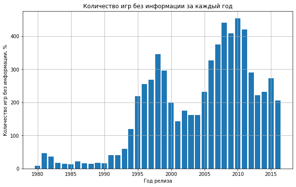

```python
plt.figure(figsize=(10,6))
plt.bar(info_df['year_of_release'], info_df['amount'])
plt.title('Количество игр без информации за каждый год')
plt.xlabel('Год релиза')
plt.ylabel('Количество игр без информации, %')
plt.grid(True)
plt.show()
```

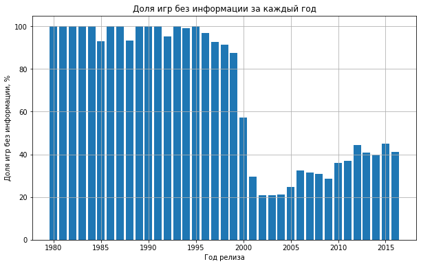

```python
plt.figure(figsize=(10,6))
plt.bar(info_df['year_of_release'], info_df['share'])
plt.title('Доля игр без информации за каждый год')
plt.xlabel('Год релиза')
plt.ylabel('Доля игр без информации, %')
plt.grid(True)
plt.show()
```

По графикам видно, что подавляющему большинству игр до 2000 года не были присвоены оценки и рейтинг. Постепенное уменьшение доли неоцененных игр началось после 1997 года, а в 2000 уменьшилось на треть - до 56%. Начиная с 2001 года, заметна тенденция увеличения доли неоцененных игр с 20% до 45% в 2015 году. Скорее всего, это связано с тем, что для отображения оценки и рейтинга игры требуется несколько лет - чем ближе к сегодняшней дате, тем больше неоцененных игр.

Вероятнее всего, сервисы по оценке возникли в промежутке между 1996 и 2000 годов, и до этого практика оценки игр и присвоения им рейтинга отсутствовала, что объясняет 90-100% доли игр без оценки и рейтинга до 1999 года.

Доля всех игр без информации, вышедших до 2000 года, занимает 28.5% от всех игр без оценок и рейтинга, т.к. за те 20 лет вышло не так много игр. 71,5% неоцененных игр было выпущено за 17 лет после 2000 года, и не все из них еще успели оценить.

### Вывод

```python
data.shape[0]
```

```
16443
```

После предобработки данных исходный датафрейм уменьшился на 272 строки (1.6%).

Наименования всех столбцов были приведены к нижнему регистру.

В столбце `'user_score'` значение `'tbd'` заменено на `NaN`. Типы данных в столбцах `'year_of_release'` и `'user_score'` были заменены на `'int'` и `'float'`соответственно.

Добавлен столбец `'total_sales'` с информацией о суммарных продажах во всех регионах.

Мы избавились от 1 явного дубликата, а также в столбце `'rating'` был обнаружен и обработан 1 дубликат среди уникальных значений.

При проверке пропущенных значений:

Причины возникновения пропущенных значений:

- в столбцах `'name'` `'genre'`, а также `'year_of_release'`, вероятнее всего, пропущенные значения возникли из-за сбоя при копировании, считывании или сохранении данных.
- в столбцах `'critic_score'`, `'user_score'` и `'rating'`, вероятно, игры изначально не имели информацию об оценках и рейтинге, так как не все игры могли быть оценены. Также играм без значения в `'rating'` могли присвоить рейтинг другими организациями, как, например PEGI, USK или BBFC, которые действуют в Европе, или же CERO, действующая в Японии.

## Исследовательский анализ данных

При проведении исследовательского анализа необходимо выяснить:

- сколько игр выпускалось в разные годы.
- как менялись продажи по платформам.
- какие платформы лидируют по продажам.
- как влияют на продажи внутри одной популярной платформы отзывы пользователей и критиков.
- общее распределение игр по жанрам. Что можно сказать о самых прибыльных жанрах.

Для дальнейшего построения сводных таблиц по суммарным продажам будем использовать функцию `games_sales_pivot`.

### Количество выпущенных игр в разные годы

Посмотрим, сколько игр выпускалось в разные годы.

```python
data['year_of_release'].value_counts().sort_index()
```

```
1980       9
1981      46
1982      36
1983      17
1984      14
1985      14
1986      21
1987      16
1988      15
1989      17
1990      16
1991      41
1992      43
1993      60
1994     121
```

[output cut: 23 more lines]

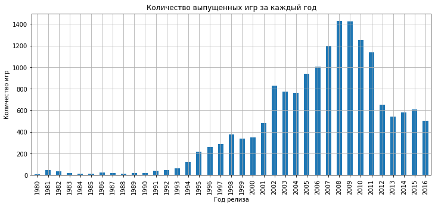

```python
data['year_of_release'].value_counts()\
                       .sort_index()\
                       .plot(kind='bar',
                             figsize=(12, 5),
                             grid=True,
                             title='Количество выпущенных игр за каждый год',
                             xlabel='Год релиза',
                             ylabel='Количество игр');
```

На графике заметно, что в период с 1980 по 1993 год индустрия игр не развивалась и держалась на одном уровне - в среднем за год выпускалось 26 игр.

В 1994 году количество выпускаемых игр по сравнению с предыдущим годом удвоилось, после чего ежегодно количество начало расти быстрыми темпами вплоть до 2008 года и десятикратно увеличилось за 15 лет.

Пик графика приходится на 2008-2009 годы - 1440 выпущенных игр, после чего с 2010 года выпуск игр пошел на спад, в 2012 количество сократилось вдвое и с тех пор количество выпускаемых игр держится на уровне 500-600 штук в год.

### Продажи по платформам

Посмотрим, как менялись продажи по платформам.

```python
games_sales_pivot(data, 'total_sales', 'platform')
```

| platform | total_sales |
| --- | --- |
| PS2 | 1233.56 |
| X360 | 961.24 |
| PS3 | 931.34 |
| Wii | 891.18 |
| DS | 802.78 |
| PS | 727.58 |
| PS4 | 314.14 |
| GBA | 312.88 |
| PSP | 289.53 |
| 3DS | 257.81 |
| PC | 255.76 |
| GB | 254.43 |
| XB | 251.57 |
| NES | 251.05 |
| N64 | 218.01 |
| SNES | 200.04 |
| GC | 196.73 |
| XOne | 159.32 |
| 2600 | 86.48 |
| WiiU | 82.19 |
| PSV | 53.81 |
| SAT | 33.59 |
| GEN | 28.35 |
| DC | 15.95 |
| SCD | 1.86 |
| NG | 1.44 |
| WS | 1.42 |
| TG16 | 0.16 |
| 3DO | 0.10 |
| GG | 0.04 |
| PCFX | 0.03 |

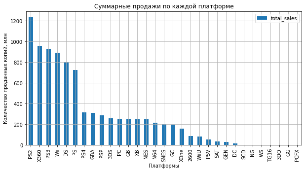

```python
games_sales_pivot(data, 'total_sales', 'platform').plot(kind='bar',
                                         figsize=(10, 5),
                                         grid=True,
                                         title=f'Суммарные продажи по каждой платформе',
                                         xlabel='Платформы',
                                         ylabel='Количество проданных копий, млн');
```

Среди платформ по количеству продаж за всё время лидируют PlayStation2, Xbox360, PlayStation3, Wii, NintendoDS и PlayStation.

Построим по платформам с наибольшими суммарными продажами распределение по годам.

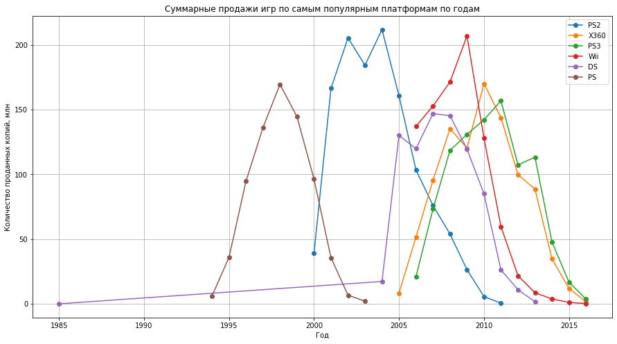

```python
for platform in games_sales_pivot(data, 'total_sales', 'platform').index[:6]:
    data[data['platform'] == platform].groupby('year_of_release')['total_sales']\
                                      .sum()\
                                      .plot(figsize=(15, 8),
                                            style='o-',
                                            label=platform)
plt.grid()
plt.legend()
plt.title('Суммарные продажи игр по самым популярным платформам по годам')
plt.xlabel('Год')
plt.ylabel('Количество проданных копий, млн');
```

На графике NintendoDS заметна аномалия - в значениях года появляпется 1985, когда как сама платформа была выпущена в 2004 году.

Изучим эту аномалию.

```python
data[(data['year_of_release'] == 1985) & (data['platform'] == 'DS')]
```

|  | name | platform | year_of_release | genre | na_sales | eu_sales | jp_sales | other_sales | critic_score | user_score | rating | total_sales |
| --- | --- | --- | --- | --- | --- | --- | --- | --- | --- | --- | --- | --- |
| 15957 | Strongest Tokyo University Shogi DS | DS | 1985 | Action | 0.0 | 0.0 | 0.02 | 0.0 | NaN | NaN | Not rated | 0.02 |

Всего одна игра.

Очевидно, что игра "Strongest Tokyo University Shogi DS" не имеет никакого отношения к платформе NintendoDS, так как она была выпущена задолго до появления этой платформы. По данной игре не удалось найти информацию. Так как мы не можем определить, к какой платформе она относится на самом деле, то лучше удалить ее из таблицы.

```python
data = data[data['name'] != 'Strongest Tokyo University Shogi DS']
```

Проверяем результат.

```python
data[(data['year_of_release'] == 1985) & (data['platform'] == 'DS')]
```

|  | name | platform | year_of_release | genre | na_sales | eu_sales | jp_sales | other_sales | critic_score | user_score | rating | total_sales |
| --- | --- | --- | --- | --- | --- | --- | --- | --- | --- | --- | --- | --- |

Мы избавились от аномалии.

Посмотрим, сколько лет составляет "срок жизни" платформ на рынке, а также через сколько лет наступает пик их популярности после первого появления на рынке.

```python
# Создаем пустой DataFrame для сохранения результатов
results = pd.DataFrame(columns=['platform', 'released', 'lifespan', 'years_to_peak'])

# Для каждой платформы
for platform in games_sales_pivot(data, 'total_sales', 'platform').index[:6]:
    platform_data = data[data['platform'] == platform]

    # Отображаем дату выхода платформы
    released = platform_data['year_of_release'].min()

    # Вычисляем срок жизни платформы
    lifespan = platform_data['year_of_release'].max() - released

    # Вычисляем, через сколько лет после даты выхода платформы наступает ее пик популярности
    peak_year = platform_data.groupby('year_of_release')['total_sales'].sum().idxmax()
    years_to_peak = peak_year - platform_data['year_of_release'].min()

    # Добавляем результаты в DataFrame
    results = results.append({'platform': platform, 'released': released, 'lifespan': lifespan, 'years_to_peak': years_to_peak}, ignore_index=True)

results
```

|  | platform | released | lifespan | years_to_peak |
| --- | --- | --- | --- | --- |
| 0 | PS2 | 2000 | 11 | 4 |
| 1 | X360 | 2005 | 11 | 5 |
| 2 | PS3 | 2006 | 10 | 5 |
| 3 | Wii | 2006 | 10 | 3 |
| 4 | DS | 2004 | 9 | 3 |
| 5 | PS | 1994 | 9 | 4 |

**Вывод**

Среди платформ по количеству продаж за всё время лидируют PlayStation2, Xbox360, PlayStation3, Wii, NintendoDS и PlayStation.

На графиках можно увидеть, в какие периоды и как долго оставались на рынке самые популярные платформы:

- в среднем платформы существуют на рынке в течение 10 лет,
- пик продаж наступает в среднем спустя 4 года после выхода платформы,
- ни одна из этих платформ уже не является актуальной в 2016 году.

### Выделение актуального периода

При анализе предыдущих данных мы выяснили, что в датафрейме много неактуальной информации, которая может нам помешать для построения прогнозов на будущий 2017 год. Выделим для дальнейшего исследования акутальный период в 3 года с 2014 по 2016 год.

```python
actual_data = data[data['year_of_release'] > 2013]
```

```python
print('Количество данных:',
      actual_data.shape[0])
actual_data.sort_values(by='year_of_release').head(10)
```

```
Количество данных: 1689
```

|  | name | platform | year_of_release | genre | na_sales | eu_sales | jp_sales | other_sales | critic_score | user_score | rating | total_sales |
| --- | --- | --- | --- | --- | --- | --- | --- | --- | --- | --- | --- | --- |
| 5246 | Thief (2014) | PS3 | 2014 | Action | 0.10 | 0.17 | 0.02 | 0.05 | NaN | NaN | Not rated | 0.34 |
| 6628 | Just Dance 2015 | PS3 | 2014 | Misc | 0.13 | 0.08 | 0.00 | 0.04 | NaN | 6.8 | E10+ | 0.25 |
| 16293 | Adventure Time: The Secret of the Nameless | X360 | 2014 | Adventure | 0.01 | 0.00 | 0.00 | 0.00 | NaN | NaN | Not rated | 0.01 |
| 6678 | Hatsune Miku: Project Diva F 2nd | PS3 | 2014 | Misc | 0.09 | 0.03 | 0.10 | 0.03 | 78.0 | 8.6 | T | 0.25 |
| 12502 | Super Robot Wars OG Saga Masou Kishin F: Coffi... | PS3 | 2014 | Strategy | 0.00 | 0.00 | 0.06 | 0.00 | NaN | NaN | Not rated | 0.06 |
| 12497 | Nazotoki Battle Tore! Densetsu no Makyuu o Fuk... | 3DS | 2014 | Action | 0.00 | 0.00 | 0.06 | 0.00 | NaN | NaN | Not rated | 0.06 |
| 6744 | Teenage Mutant Ninja Turtles: Danger of the Ooze | PS3 | 2014 | Adventure | 0.11 | 0.09 | 0.00 | 0.04 | NaN | 5.9 | E10+ | 0.24 |
| 6754 | The Walking Dead: Season Two | PS4 | 2014 | Adventure | 0.10 | 0.09 | 0.01 | 0.04 | NaN | NaN | Not rated | 0.24 |
| 12470 | Transformer: Rise of the Dark Spark | WiiU | 2014 | Action | 0.04 | 0.01 | 0.00 | 0.01 | NaN | NaN | Not rated | 0.06 |
| 6772 | Trials Fusion | XOne | 2014 | Racing | 0.12 | 0.10 | 0.00 | 0.02 | 80.0 | 7.1 | E10+ | 0.24 |

У нас осталось 10.2% данных, которые относятся к актуальным. В дальнейшем исследовании мы будем использовать только их.

### Актуальные лидирующие платформы

Изучим лидирующие по продажам платформы на момент 2016 года.

```python
games_sales_pivot(actual_data[actual_data['year_of_release'] == 2016], 'total_sales', 'platform')
```

| platform | total_sales |
| --- | --- |
| PS4 | 69.25 |
| XOne | 26.15 |
| 3DS | 15.14 |
| PC | 5.25 |
| WiiU | 4.60 |
| PSV | 4.25 |
| PS3 | 3.60 |
| X360 | 1.52 |
| Wii | 0.18 |

Построим график по актуальному периоду и еще по 2 предыдущим годам, чтобы лучше было видно динамику роста и падения популярности платформ.

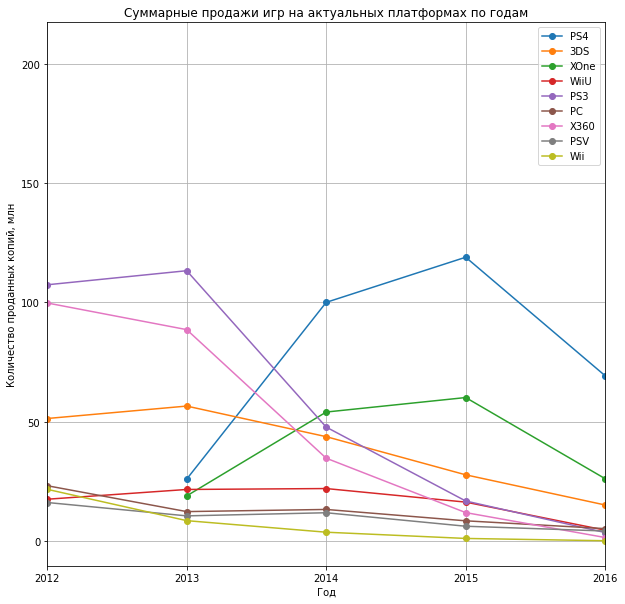

```python
for platform in data[data['year_of_release'] == 2016]['platform'].unique():
    data[data['platform'] == platform].groupby('year_of_release')['total_sales'].sum()\
                                                    .plot(figsize=(10, 10),
                                                          style='o-',
                                                          label=platform)

plt.grid()
plt.legend()
plt.xlim(2012, 2016)
plt.xticks(range(2012, 2017))
plt.title('Суммарные продажи игр на актуальных платформах по годам')
plt.xlabel('Год')
plt.ylabel('Количество проданных копий, млн');
```

Изучим диаграмму размаха.

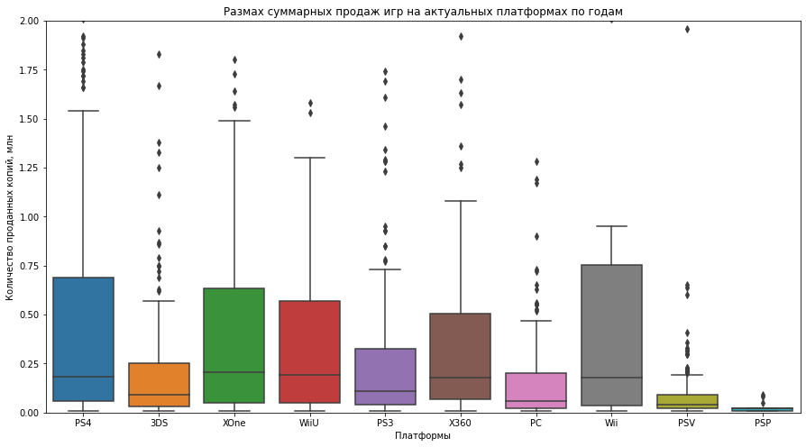

```python
plt.figure(figsize=(15, 8))
sns.boxplot(data=actual_data, x='platform', y='total_sales')
plt.ylim(0, 2)
plt.title('Размах суммарных продаж игр на актуальных платформах по годам')
plt.xlabel('Платформы')
plt.ylabel('Количество проданных копий, млн');
```

На графике можно увидеть, что лидерами по продажам в актуальный период являются PlayStation4 и XboxOne, которые пришли на замену устаревшим PlayStation3 и Xbox360. Обе платформы были выпущены в 2013 году. Видно, что на данный момент их показатели растут, но по 2016 году сказать этого еще нельзя, т.к. данные за этот год неполные, но, определенно, они имеют лучшие результаты.

Самые потенциально прибыльные платформы - PlayStation4 и XboxOne. Можно предположить, что в 2017-2018 годах эти платформы могут достигнуть пика своей популярности.

### Влияние отзывов на продажи игр

Посмотрим, как влияют на продажи отзывы пользователей и критиков по каждой платформе.

Сперва получим список всех уникальных платформ, которые имеют оценки в столбцах `'critic_score'` и `'user_score'`.

```python
platforms = actual_data.dropna(subset=['critic_score', 'user_score'])['platform'].unique()
```

Построим диаграмму рассеяния между отзывами и продажами.

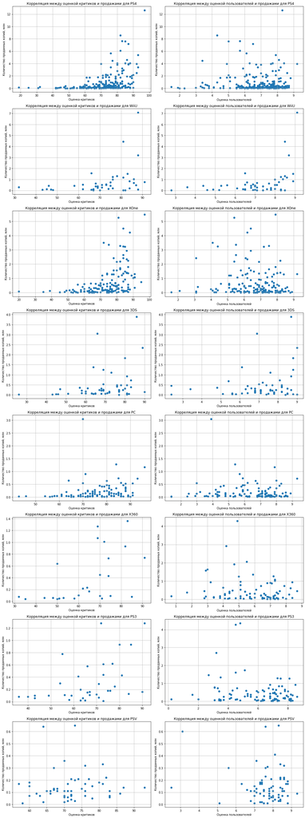

```python
# Создаем фигуру с двумя столбцами графиков (один для каждого типа корреляции)
fig, axs = plt.subplots(len(platforms), 2, figsize=(15, 5 * len(platforms)))

for i, platform in enumerate(platforms):
    platform_data = actual_data[actual_data['platform'] == platform]

    # Построение диаграммы рассеяния для 'critic_score' и 'total_sales'
    axs[i, 0].scatter(platform_data['critic_score'], platform_data['total_sales'])
    axs[i, 0].grid(True)
    axs[i, 0].set_title(f'Корреляция между оценкой критиков и продажами для {platform}')
    axs[i, 0].set_xlabel('Оценка критиков')
    axs[i, 0].set_ylabel('Количество проданных копий, млн')

    # Построение диаграммы рассеяния для 'user_score' и 'total_sales'
    axs[i, 1].scatter(platform_data['user_score'], platform_data['total_sales'])
    axs[i, 1].grid(True)
    axs[i, 1].set_title(f'Корреляция между оценкой пользователей и продажами для {platform}')
    axs[i, 1].set_xlabel('Оценка пользователей')
    axs[i, 1].set_ylabel('Количество проданных копий, млн')

plt.tight_layout()
plt.show()
```

Посчитаем корреляцию между отзывами и продажами.

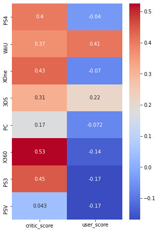

```python
# Создаем пустой DataFrame для хранения результатов и преобразуем данные в числовой формат
corr_data = pd.DataFrame(index=platforms, columns=['critic_score', 'user_score']).astype(float)

# Вычисляем корреляцию для каждой платформы
for platform in platforms:
    platform_data = actual_data[actual_data['platform'] == platform]
    corr_data.loc[platform, 'critic_score'] = platform_data['critic_score'].corr(platform_data['total_sales'])
    corr_data.loc[platform,'user_score'] = platform_data['user_score'].corr(platform_data['total_sales'])

# Отображаем данные с цветовой индикацией
plt.figure(figsize=(5, 8))
sns.heatmap(corr_data, annot=True, cmap='coolwarm');
```

Можно заметить, что в общем оценки критиков имеют большее значение, чем оценки пользователей. Когда как почти у всех платформ наблюдается средняя прямая корреляция между оценкой критиков и продажами, то между оценкой пользователей и продажами она очень слабая или не наблюдается вовсе. Чем выше оценка критиков, тем больше продаж. Покупатели склонны больше доверять отзывам критиков, чем отзывам других пользователей.

В списке выделяются платформы WiiU и Nintendo3DS, у которых значение оценки критиков и пользователей имеют почти одинаковое влияние на продажи. Также можно добавить, что у платформы PlayStationVita и у персональных компьютеров никакие оценки почти не имеют влияния на продажи.

Самая заметная зависимость продаж от оценки критиков видна у таких платформ, как:

- Xbox360 (53%),
- PlayStation3 (45%),
- XboxOne (43%),
- PlayStation4 (40%).

### Распределение игр по жанрам

Изучим, сколько игр было выпущено по каждому жанру в актуальный период.

```python
actual_data['genre'].value_counts()
```

```
Action          619
Role-Playing    221
Adventure       185
Sports          161
Shooter         128
Misc            113
Racing           69
Fighting         60
Simulation       44
Platform         38
Strategy         37
Puzzle           14
Name: genre, dtype: int64
```

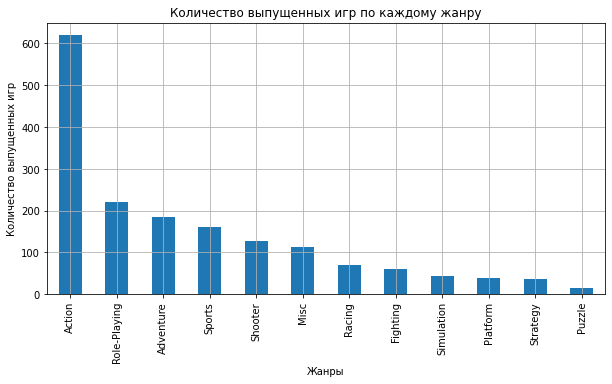

```python
actual_data['genre'].value_counts()\
                    .plot(kind='bar',
                          figsize=(10, 5),
                          grid=True,
                          title=f'Количество выпущенных игр по каждому жанру',
                          xlabel='Жанры',
                          ylabel='Количество выпущенных игр');
```

Экшн-игры имеют наибольшее разнообразие и занимает 36.7% долю на всем рынке - каждая третья игра относится к этому жанру.

Самый редкий жанр - головоломки, которые занимают всего 0.8% долю на рынке.

Изучим продажи игр по каждому жанру.

```python
games_sales_pivot(actual_data, 'total_sales', 'genre')
```

| genre | total_sales |
| --- | --- |
| Action | 199.36 |
| Shooter | 170.94 |
| Sports | 109.48 |
| Role-Playing | 101.44 |
| Misc | 37.55 |
| Fighting | 28.22 |
| Racing | 27.52 |
| Platform | 18.09 |
| Adventure | 17.55 |
| Simulation | 13.13 |
| Strategy | 3.96 |
| Puzzle | 2.21 |

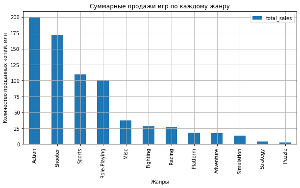

```python
games_sales_pivot(actual_data, 'total_sales', 'genre').plot(kind='bar',
                                             figsize=(10, 5),
                                             grid=True,
                                             title=f'Суммарные продажи игр по каждому жанру',
                                             xlabel='Жанры',
                                             ylabel='Количество проданных копий, млн');
```

Экшн-игры также в лидерах по продажам игр. Но в сравнении с количеством игр этого жанра доля продаж уже не такая подавляющая - 27.4%. Следом по прибыльности идут такие жанры, как шутеры (23.4%), спортивные игры (15%) и РПГ (13.9%).

Несмотря на меньшую долю продаж, жанр шутер может оказаться более выгодным, т.к. в нем конкуренция ниже из-за более низкого количества игр, чем среди экшн-игр.

Самыми непопулярными жанрами оказались головоломки (0.3%) и стратегические игры (0.5%).

### Вывод

С 1994 года индустрия игр активно развивалась вплоть до 2008 года, достигнув пика в 2008-2009 годы, после чего количество ежегодно выпускаемых игр пошел на спад, достигнув плато в 2012 году, где выпускают в среднем 500-600 игр в год до 2016 года включительно.

Среди платформ по количеству продаж за всё время лидируют PlayStation2, Xbox360, PlayStation3, Wii, NintendoDS и PlayStation. В среднем платформы существуют на рынке в течение 9-11 лет, пик продаж наступает спустя 3-5 лет после выхода платформы.

Для дальнейшего исследования данных был выделен акутальный период в 3 года с 2014 по 2016 год, что составляет 10.2% от всех имеющихся данных.

Лидерами по продажам в актуальный период являются PlayStation4 и XboxOne, которые пришли на замену устаревшим PlayStation3 и Xbox360. Можно предположить, что в 2017-2018 годах эти платформы могут достигнуть пика своей популярности.

В общем оценки критиков имеют большее значение, чем оценки пользователей. Покупатели склонны больше доверять отзывам критиков, чем отзывам других пользователей.

Экшн-игры имеют наибольшее разнообразие на всем рынке, а также они лидируют по продажам. Также среди популярных жанров мы видим шутеры, спортивные игры и РПГ. Несмотря на меньшую долю продаж, жанр шутер может оказаться более выгодным, т.к. в нем конкуренция ниже из-за более низкого количества игр, чем среди экшн-игр. Самые непопулярные жанры - головоломки и стратегические игры.

## Составление портрета пользователя каждого региона

Необходимо определить для пользователя каждого региона (NA, EU, JP):

- Самые популярные платформы (топ-5).
- Самые популярные жанры (топ-5).
- Влияние рейтинга ESRB на продажи в отдельном регионе.

Для построения диаграмм по рассматриваемым вопросам будем использовать функцию `regions_pie_plots`.

### Самые популярные платформы в регионах

Построим график с ТОП-5 платформ в регионах.

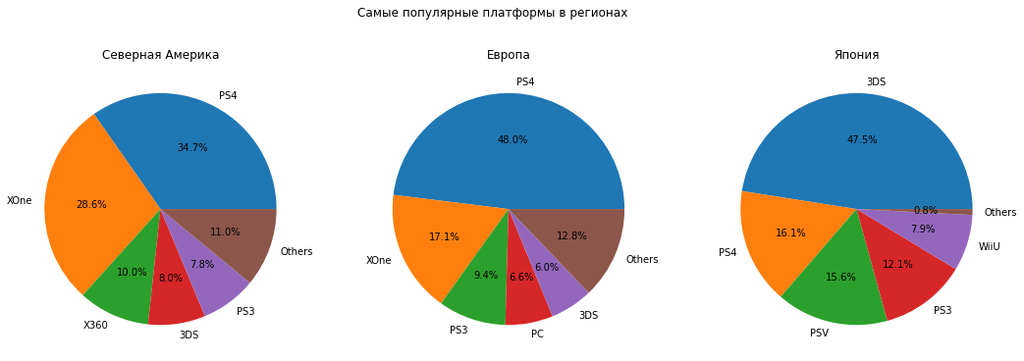

```python
regions_pie_plots('platform', 'платформы')
```

**Северная Америка:**

В северной Америке предпочитают домашние консоли. Пользователей можно поделить на два лагеря - приверженцев японских консолей PlayStation и любителей отечественных консолей Xbox, хотя и последние отстают на 4% по популярности. Самые популярные консоли среди северноамериканских пользователей: PlayStation 4 и 3 поколения, Xbox One и Xbox 360, а также есть 8% пользователей портативной Nintendo3DS. Другие консоли среди пользователей встречаются не часто.

**Европа:**

Заметно сходство между графиками Северной Америки и Европы. Спросом пользуются домашние консоли. Больше половины европейских пользователей предпочитают PlayStation - 4 поколение остается абсолютным лидером, 3 поколение занимает третье место. На втором месте по популярности стоит Xbox One, но с очень большим отрывом, в отличии от Америки - их в 3 раза меньше, чем PlayStation4. Также есть некоторое количество пользователей, которые предпочитают консолям персональные компьютеры. Пятерку самых популярных платформ закрывает портативная консоль Nintendo3DS. Другие консоли среди пользователей встречаются не часто.

**Япония:**

Большинство японских пользователей предпочитают портативные игровые консоли, также они предпочитают пользоваться консолями отечественного производства. Самые популярные консоли среди пользователей Японии: портативные Nintendo3DS и PlayStation Vita, домашние консоли PlayStation 4 и 3 поколения, а также WiiU, другие консоли встречаются крайне редко.

### Самые популярные жанры в регионах

Построим график с ТОП-5 жанров в регионах.

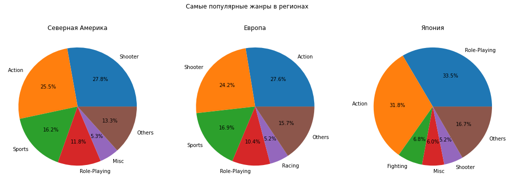

```python
regions_pie_plots('genre', 'жанры')
```

**Северная Америка:**

Североамериканские пользователи предпочитают шутеры и экшн-игры, которые занимают более половины рынка. Среди них высокий спрос на динамичные игры с элементами сражения и конкуренции. Также популярны спортивные игры. Это может отражать интерес пользователей к спортивной культуре. Ролевые игры занимают четвертое место по популярности, но с большим отрывом от лидеров. Часть пользователей Северной Америки заинтересованы в сложных и длительных играх с развитой сюжетной линией. Пятую часть занимают игры других жанров или которые не подходят под критерии других категорий или жанров.

**Европа:**

Предпочтения европейских пользователей очень схожи с североамериканскими. Пользователи Европы также отдают предпочтение экшн-играм и шутерам, с тем лишь отличием, что экшн чуть более популярен, чем в Америке. На третьем месте по популярности также стоят спортивные игры. Ролевые игры также занимают значительную часть рынка. В отличие от Северной Америки, гонки занимают пятое место по доле рынка в Европе среди всех жанров. Пользователи любят участвовать в автомобильных соревнованиях, испытывать ощущения скорости и маневренности, а также настраивать свои автомобили по своему вкусу.

**Япония:**

Пользователи в этом регионе отличаются от других регионов по своим предпочтениям в жанрах игр. Самым популярным жанром является ролевой, который занимает треть рынка. Это может свидетельствовать о том, что пользователи любят игры с глубоким и захватывающим сюжетом и возможностью влиять на ход игры своими выборами. На втором и третьем месте по популярности стоят экшн и файтинг. Это может говорить о том, что пользователи Японии также ценят динамичные игры, в которых требуется ловкость, реакция и мастерство. Шутеры занимают последнее место в ТОПе, что может быть связано с тем, что японские пользователи менее заинтересованы в играх с реалистичным сражением и военной тематикой, а также с тем, что шутеры лучше подходят для игры на консолях и ПК, чем на портативных устройствах.

### Влияние рейтинга ESRB на продажи регионах

Изучим долю продаж игр по каждому рейтингу.

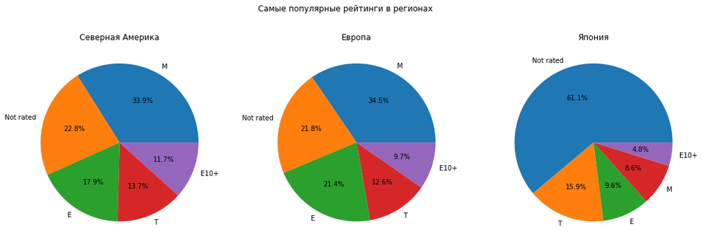

```python
regions_pie_plots('rating', 'рейтинги')
```

**Северная Америка:**

В этом регионе самым популярным рейтингом является M, который занимает треть рынка. Это может свидетельствовать о том, что в Северной Америке большой спрос на игры с высокой степенью реализма и взрослой тематики, такие как шутеры и экшн-игры, которые преобладают в жанрах в этом регионе. На втором месте по популярности стоят игры, которые не получили рейтинга от ESRB. Вероятно, в Северной Америке многие игроки не обращают внимания на рейтинг ESRB или также категория Not rated может включать в себя игры, которые не получили рейтинга от ESRB, но получили рейтинг от других систем. На третьем месте по популярности стоит рейтинг E, который предназначен для всех возрастных групп. Эта категория также имеет неплохие продажи, что может свидетельствовать о том, что в Северной Америке есть аудитория, которая предпочитает более легкие и добродушные игры. На четвертом и пятом местах по популярности стоят рейтинги T и E10+, которые предназначены для подростков и детей старше 10 лет соответственно. Эти категории имеют относительно низкие продажи, что может говорить о том, что в Северной Америке подростковая и детская аудитория не такая большая или не такая активная, как взрослая или всеобщая.

**Европа:**

Снова показатели сходятся с североамериканскими. В этом регионе также самым популярным рейтингом является M, который занимает треть рынка. Это может свидетельствовать о том, что в Европе также большой спрос на игры с высокой степенью реализма и взрослой тематики, такие как шутеры и экшн-игры, которые также доминируют по жанрам в этом регионе. На втором и третьем местах по популярности стоят категории Not rated и E, которые занимают примерно одинаковую долю рынка. Это может свидетельствовать о том, что в Европе есть разнообразие вкусов и предпочтений игроков, а также разные стандарты и регуляции для игр в разных странах. Категория E может включать в себя игры, которые подходят для всех возрастных групп. На двух последних местах по популярности также стоят рейтинги T и E10+ для подростков и детей старше 10 лет. В Европе подростковая и детская аудитория не такая большая или не такая активная, как в Северной Америке.

**Япония:**

В этом регионе самым большую долю занимают игры без рейтинга ERSB, почти две трети рынка. Это может свидетельствовать о том, что в Японии система рейтингов ESRB не такая распространенная или важная, как в других регионах. На втором месте по популярности стоит рейтинг T, который предназначен для подростков 13 лет и старше. Эта категория занимает около шестой части рынка, что может говорить о том, что в Японии подростковая аудитория чуть более активна, чем в других регионах. На третьем и четвертом местах по популярности стоят рейтинги E и M, которые предназначены для всех возрастных групп и для взрослых 17 лет и старше соответственно. Эти категории занимают около десяти процентов рынка каждая, что может говорить о том, что в Японии есть аудитория, которая предпочитает более легкие и добродушные игры, а также аудитория, которая заинтересована в играх с высоким уровнем реализма и насилия, но они не такие большие или активные, как в других регионах. На пятом месте по популярности стоит рейтинг E10+, который предназначен для детей старше 10 лет. Эта категория занимает около пяти процентов рынка, что может говорить о том, что в Японии детская аудитория не такая большая, как в других регионах, или что в Японии дети играют в игры с более высокими рейтингами, чем E10+.

### Вывод

На рынках Северной Америки и Европы было замечено очень много совпадений, что говорит о схожести менталитета. В Северной Америке и Европе доминируют домашние консоли, особенно PlayStation 4. Xbox One также популярен в Северной Америке, но значительно отстает от PlayStation в Европе. Также в Европе выделяется категория пользователей, предпочитающих персональные компьютеры.

Самые популярные жанры игр в этих регионах - это шутеры и экшн-игры, которые отражают интерес пользователей к динамичным и конкурентным играм. Спортивные игры также пользуются спросом, особенно в Европе, где гонки занимают пятое место по популярности. Ролевые игры имеют ниже среднего уровня популярности, но все же привлекают часть аудитории, которая заинтересована в сложных и длительных играх с развитой сюжетной линией.

В Японии доминируют портативные консоли, особенно Nintendo 3DS и PlayStation Vita. Домашние консоли PlayStation 4 и 3 поколения также популярны, но в меньшей степени. Пользователи Японии предпочитают консоли отечественного производства, такие как PlayStation и Nintendo.

Самый популярный жанр игр в этом регионе - это ролевой, который занимает треть рынка. Экшн и файтинг также популярны, так как они отражают интерес пользователей к динамичным и мастерским играм. Шутеры занимают последнее место по популярности.

## Проверка гипотез

Проверим гиспотезы:

- Средние пользовательские рейтинги платформ Xbox One и PC одинаковые;
- Средние пользовательские рейтинги жанров Action и Sports разные.

Для проверки этих гипотез мы используем t-тест для двух независимых выборок. Этот тест используется для сравнения средних значений двух независимых групп, чтобы определить, есть ли статистически значимые различия между ними.

Зададим пороговое значение alpha в 5%.

```python
alpha = 0.05
```

### Пользовательские рейтинги платформ Xbox One и PC

**Гипотеза**: Средние пользовательские рейтинги платформ Xbox One и PC одинаковые.

$H_0$: Средний пользовательский рейтинг платформы Xbox One **равен** среднему пользовательскому рейтингу PC.

$H_1$: Средний пользовательский рейтинг платформы Xbox One **не равен** среднему пользовательскому рейтингу PC.

```python
# выберем данные для Xbox One и PC
xone_data = actual_data[actual_data['platform'] == 'XOne']['user_score']
pc_data = actual_data[actual_data['platform'] == 'PC']['user_score']

# проведем t-тест
result_platform = stats.ttest_ind(xone_data,
                                  pc_data,
                                  equal_var=False,
                                  nan_policy='omit')

print('Платформы XboxOne и PC:')
print('p-значение:', result_platform.pvalue)
if (result_platform.pvalue < alpha):
    print('Отвергаем нулевую гипотезу, средние пользовательские рейтинги отличаются')
else:
    print('Не получилось отвергнуть нулевую гипотезу, средние пользовательские рейтинги не отличаются')
```

```
Платформы XboxOne и PC:
p-значение: 0.11601398086668943
Не получилось отвергнуть нулевую гипотезу, средние пользовательские рейтинги не отличаются
```

В результате t-теста мы не смогли отвергнуть нулевую гипотезу. Это означает, что на основании имеющихся данных мы не можем утверждать, что средние пользовательские рейтинги для платформ Xbox One и PC отличаются.

### Пользовательские рейтинги жанров Action и Sports

**Гипотеза**: Средние пользовательские рейтинги жанров Action и Sports разные.

$H_0$: Средний пользовательский рейтинг жанра Action **равен** среднему пользовательскому рейтингу жанра Sports.

$H_1$: Средний пользовательский рейтинг жанра Action **не равен** среднему пользовательскому рейтингу жанра Sports.

```python
# выберем данные для жанров Action и Sports
action_data = actual_data[actual_data['genre'] == 'Action']['user_score']
sports_data = actual_data[actual_data['genre'] == 'Sports']['user_score']

# проведем t-тест
result_genre = stats.ttest_ind(action_data,
                               sports_data,
                               equal_var=False,
                               nan_policy='omit')

print('Жанры Action и Sports:')
print('p-значение:', result_genre.pvalue)
if (result_genre.pvalue < alpha):
    print('Отвергаем нулевую гипотезу, средние пользовательские рейтинги отличаются')
else:
    print('Не получилось отвергнуть нулевую гипотезу, средние пользовательские рейтинги не отличаются')
```

```
Жанры Action и Sports:
p-значение: 1.182555038264477e-14
Отвергаем нулевую гипотезу, средние пользовательские рейтинги отличаются
```

В этом случае в результате t-теста мы отвергли нулевую гипотезу. Это означает, что на основании имеющихся данных мы можем утверждать, что существуют статистически значимые различия между средними пользовательскими рейтингами для жанров Action и Sports.

### Вывод

Мы проверили гипотезы и получили следующие результаты:

- Нулевая гипотеза не отвергается. На основании имеющихся данных мы не можем утверждать, что средние пользовательские рейтинги для платформ Xbox One и PC отличаются.
- Нулевая гипотеза отвергается. На основании имеющихся данных мы можем утверждать, что существуют статистически значимые различия между средними пользовательскими рейтингами для жанров Action и Sports.

Однако стоит помнить, что эти данные не подтверждают ту или иную гипотезу, а лишь не противоречат ей.

## Общий вывод

Были проанализированы данные и проверены некоторые гипотезы, которые могут помочь бизнесу вырасти. Полученные результаты могут быть использованы для дальнейшего улучшения работы магазина. В ходе проведенного анализа данных мы выяснили:

**В процессе первичного изучения и предобработки данных:**

- Данные представлены за период с 1980 по 2016 годы, но за последний год данные неполные.
- Мы привели наименования столбцов к нижнему регистру.
- Произвели замену типов данных в столбцах `'year_of_release'` и `'user_score'` на `'int'` и `'float'`соответственно.
- Добавлен столбец `'total_sales'` с информацией о суммарных продажах во всех регионах.
- Была проведена работа по удалению 1 явного и исправлению 1 неявного дубликата среди уникальных значений столбца `'rating'`.
- В данных пропущенные значения занимали 12.1% от всех данных таблицы, 4.5% было обработано, но также добавилось 1.3% за счет замещения значения `'tbd'` в столбце `'user_score'` на `NaN`.
- Пропущенные значения в столбцах `'name'` `'genre'`, а также `'year_of_release'` могли возникнуть по технической причине, а в `'critic_score'`, `'user_score'` и `'rating'`, вероятнее всего, изначально данные отсутствовали.

**После проведения анализа данных мы сделали следующие выводы:**

- С 1994 года индустрия игр активно развивалась вплоть до 2008 года, достигнув пика в 2008-2009 годы, после чего количество ежегодно выпускаемых игр пошел на спад, достигнув плато в 2012 году, где выпускают в среднем 500-600 игр в год до 2016 года включительно.
- Среди платформ по количеству продаж за всё время лидируют PlayStation2, Xbox360, PlayStation3, Wii, NintendoDS и PlayStation. В среднем платформы существуют на рынке в течение 9-11 лет, пик продаж наступает спустя 3-5 лет после выхода платформы.
- Для дальнейшего исследования данных был выделен акутальный период в 3 года с 2014 по 2016 год, что составляет 10.2% от всех имеющихся данных.
- Лидерами по продажам в актуальный период являются PlayStation4 и XboxOne, которые пришли на замену устаревшим PlayStation3 и Xbox360. Можно предположить, что в 2017-2018 годах эти платформы могут достигнуть пика своей популярности.
- В общем оценки критиков имеют большее значение, чем оценки пользователей. Покупатели склонны больше доверять отзывам критиков, чем отзывам других пользователей.
- Экшн-игры имеют наибольшее разнообразие на всем рынке, а также они лидируют по продажам. Несмотря на меньшую долю продаж, жанр шутер может оказаться более выгодным, т.к. в нем конкуренция ниже из-за более низкого количества игр, чем среди экшн-игр. Самые непопулярные жанры - головоломки и стратегические игры.

**При составлении портрета пользователей каждого региона мы выяснили следующее:**

*Северная Америка:*

- Самые популярные консоли: домашние в большей степени - PlayStation 4 и 3 поколения, Xbox One и 360, портативные - Nintendo 3DS.
- Самые популярные жанры: Shooter, Action, Sports, RPG, Misc.
- Влияние рейтинга ERSB на продажи: существенное влияние - треть продаж приходится на категорию "Для взрослых", вторая треть приходится на игры категории "Для всех" и "Для подростков". Игры без рейтинга занимают пятую часть от всех продаж.

*Европа:*

- Самые популярные консоли: домашние в большей степени - PlayStation 4 и 3 поколения, Xbox One, портативные - Nintendo 3DS, а также персональные компьютеры.
- Самые популярные жанры: Action, Shooter, Sports, RPG, Racing.
- Влияние рейтинга ERSB на продажи: существенное влияние - треть продаж приходится на категорию "Для взрослых", вторая треть приходится на игры категории "Для всех" и "Для подростков". Игры без рейтинга занимают пятую часть от всех продаж.

*Япония:*

- Самые популярные консоли: в большей степени портативные - Nintendo 3DS
- Самые популярные жанры: RPG, Action, Fighting, Misc, Shooter.
- Влияние рейтинга ERSB на продажи: нет влияния. Игры без рейтинга занимают две трети от доли продаж, лишь четверть занимают игры, имеющие категории "Для всех" и "Для подростков". Категория "Для взрослых" не популярна в Японии.

Менталитет пользователей Северной Америки и Европы очень схож, когда как Япония очень сильно отличается от них.

**Мы проверили гипотезы и получили следующие результаты:**

- Мы не можем отвергнуть нулевую гипотезу о том, что средний пользовательский рейтинг платформы Xbox One равен среднему пользовательскому рейтингу PC. На основании имеющихся данных мы не можем утверждать, что средние пользовательские рейтинги для платформ Xbox One и PC отличаются.
- Мы отвергаем нулевую гипотезу о том, что средний пользовательский рейтинг жанра Action равен среднему пользовательскому рейтингу жанра Sports. На основании имеющихся данных мы можем утверждать, что существуют статистически значимые различия между средними пользовательскими рейтингами для жанров Action и Sports.

**На основе проведенного анализа, мы можем дать следующие рекомендации:**

- Стоит следить за трендами и новинками в индустрии игр, особенно за платформами PlayStation 4 и Xbox One, которые являются лидерами по продажам в актуальный период. Эти платформы могут достигнуть пика своей популярности в ближайшие годы, поэтому важно предлагать игры, которые подходят для этих платформ и удовлетворяют потребности их пользователей.
- Необходимо учитывать различия в предпочтениях пользователей в разных регионах. В Северной Америке и Европе популярны шутеры и экшн-игры, в Японии - ролевые и файтинги. Также в Японии больше спрос на портативные консоли, в то время как в других регионах - на домашние. Поэтому важно адаптировать свой ассортимент и маркетинговую стратегию в зависимости от рынка, на который вы нацелены.
- Обращать внимание на оценки критиков, так как они имеют большее значение, чем оценки пользователей. Покупатели склонны больше доверять отзывам критиков, чем отзывам других пользователей. Поэтому важно создавать качественные и привлекательные игры, которые получат высокие оценки от критиков и привлекут внимание покупателей.